# Reproducible Research: Peer Assessment 1

## Loading and preprocessing the data

First we downoald the Activity monitoring data if they are still not downloaded and load them into a data frame.

```r
if(!file.exists('activity.csv')){
    unzip("activity.zip")
}
activity <- read.csv("activity.csv", na.strings = "NA")
```

We need to transform the **date** into a proper format.

```r
activity$date <- as.Date(activity$date, format = "%Y-%m-%d")
```

## What is mean total number of steps taken per day?

Here is how we can produce a histogram of the total number of steps taken each day. The Mean and the Median are calculated over the total number of steps. Here we will use **ddply** to summarize the date:

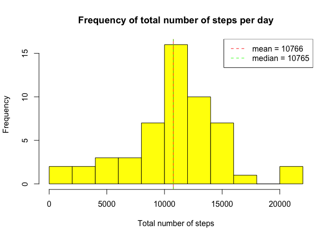

```r
day.activity <- ddply(activity, .(date), summarize, total.steps = sum(steps))
mu <- mean(day.activity$total.steps, na.rm = TRUE)
med <- median(day.activity$total.steps, na.rm = TRUE)

hist(day.activity$total.steps,
     main = "Frequency of total number of steps per day",
     xlab = "Total number of steps",
     breaks = 10,
     col = "yellow")

abline(v=mu, col = c("red"))
abline(v=med, col = c("green"), lty = 2)
legend("topright", c(paste("mean =", round(mu)),
                     paste("median =", round(med))),
       col=c("red","green"),
       lwd = 1, lty=2)
```

## What is the average daily activity pattern?

Here we can use the **aggregate** method to summarize the date:

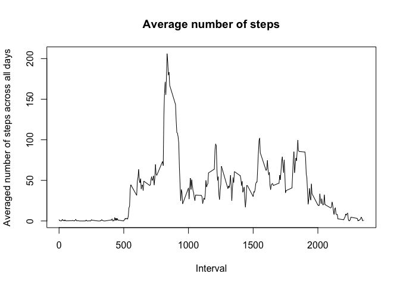

```r
interval.activity <- aggregate(activity$steps, by = list(activity$interval),
                               mean, na.rm = TRUE, na.action = NULL)
names(interval.activity) <- c("interval","average.steps")

plot(interval.activity$interval, interval.activity$average.steps,
     main="Average number of steps",
     xlab="Interval",
     ylab="Averaged number of steps across all days",
     type="l")
```

The 5-minute interval, which contains the maximum number of steps across all days could be found as follow:

```r
m <- max(interval.activity$average.steps)
pik <- interval.activity[which(interval.activity$average.steps==m), 1]
pikH <- floor(pik/60)
pikM <- pik - pikH*60
paste("The pik interval ", pik, " in time format HH:MM = ", pikH ,":", pikM, sep = "")
```

[1] “The pik interval 835 in time format HH:MM = 13:55”

## Imputing missing values

First we will find all missing values:

```r
activity$interval <- as.factor(activity$interval)
interval.activity$interval <- as.factor(interval.activity$interval)

idxNA <- is.na(activity$steps)
sum(idxNA)
```

[1] 2304

We see there are a quite few of them. To get a better approximation of the steps frequency, we will substitute this missing values with already calculated interval activity from the known data.

```r
activityIMV <- activity
activityIMV[idxNA,"steps"] <- interval.activity[activityIMV[idxNA, "interval"],
                                               "average.steps"]

day.activityIMV <- ddply(activityIMV, .(date), summarize, total.stepsIMV = as.integer(sum(steps)))
muIMV <- mean(day.activityIMV$total.stepsIMV, na.rm = TRUE)
medIMV <- median(day.activityIMV$total.stepsIMV, na.rm = TRUE)

day.activityMerged <- merge(day.activity, day.activityIMV, by=1)
```

With so inputed missing values the frequency diagram looks like this:

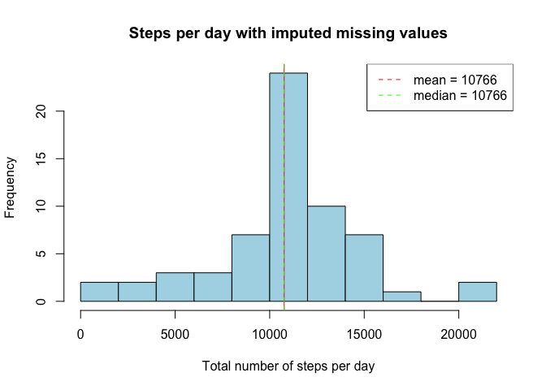

```r
hist(day.activityMerged$total.stepsIMV, xlab="Total number of steps per day", main="Steps per day with imputed missing values", col="light blue", breaks = 10)

abline(v=muIMV, col = c("red"))
abline(v=medIMV, col = c("green"), lty = 2)
legend("topright", c(paste("mean =", round(muIMV)),
                     paste("median =", round(medIMV))),
       col=c("red","green"),
       lwd = 1, lty=2)
```

## Are there differences in activity patterns between weekdays and weekends?

First we will separate weekends from weekdays using the date with imputed missing values:

```r
activityIMV$dayofweek <- sapply(activityIMV$date, FUN = weekdays)

wday <- function(date) {
    ifelse(date %in% c("Saturday", "Sunday"), "Weekend", "Weekday")
}

activityIMV$wday <- sapply(activityIMV$dayofweek, FUN = wday)
```

Let’s see the difference between the averge number of steps taken on weekdays and weekends.

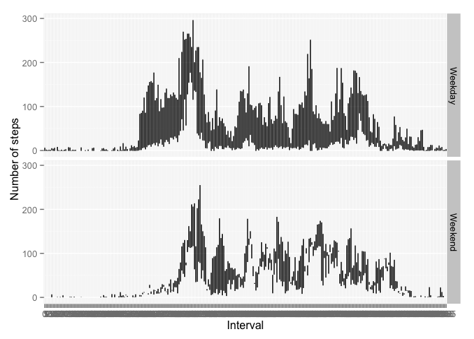

```r
aggr <- aggregate(steps ~ interval + wday + dayofweek , data=activityIMV, mean)

ggplot(aggr, aes(interval, steps)) +
    facet_grid(wday ~ .) +
    geom_line() +
    xlab("Interval") + ylab("Number of steps")
```